# Esercitazione Modulo 3A

## 2.4

Ripetere i punti 1-4 dell’esercizio precedente per le variabili `corso` ed `esito`. Quale corso di laurea è il più rappresentato nel campione? Qual è la percentuale di studenti che ha superato l’esame?

```r
# corso
tab_corso = table(dati$corso)
tab_corso
```

```
  Economia Ingegneria Psicologia
        55         34         71
```

```r
round(prop.table(tab_corso) * 100, 1)
```

```
  Economia Ingegneria Psicologia
      34.4       21.2       44.4
```

```r
# esito
tab_esito = table(dati$esito)
tab_esito
```

```
Non superato     Superato
          70           90
```

```r
round(prop.table(tab_esito) * 100, 1)
```

```
Non superato     Superato
        43.8         56.2
```

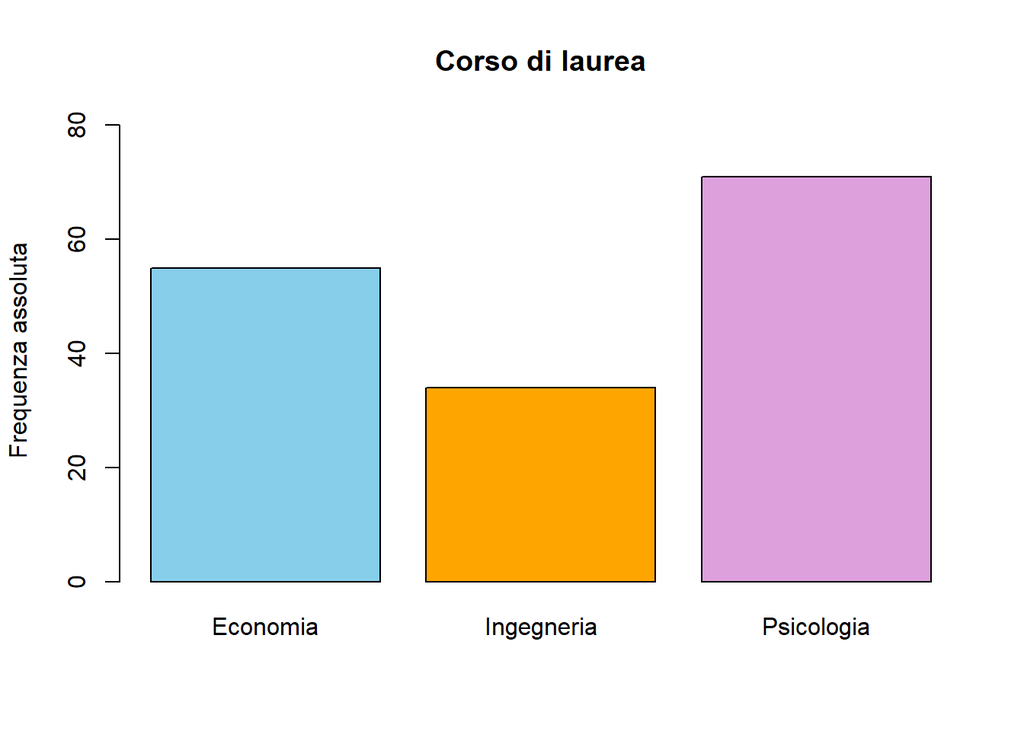

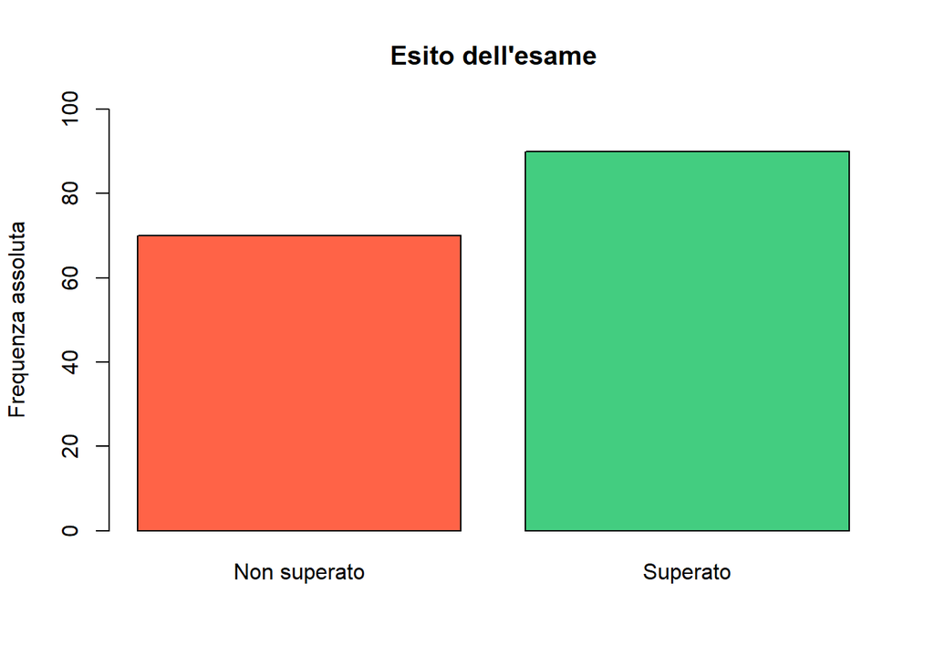

```r
barplot(tab_corso,
        col = c("skyblue", "orange", "plum"),
        main = "Corso di laurea",
        ylab = "Frequenza assoluta",
        ylim = c(0, max(tab_corso) + 10))
barplot(tab_esito,
        col = c("tomato", "seagreen3"),
        main = "Esito dell'esame",
        ylab = "Frequenza assoluta",
        ylim = c(0, max(tab_esito) + 10))
```

Il corso più rappresentato è Psicologia (71 studenti, 44.4% del campione). Il 56.2% degli studenti ha superato l’esame (90 su 160).

## 2.5

Per la variabile `ore_studio`:

1. calcolare le principali statistiche descrittive (`summary()`)
2. rappresentare la distribuzione con un **istogramma** (`hist()`)
3. rappresentare la distribuzione con un **boxplot** (`boxplot()`)
4. commentare brevemente la forma della distribuzione

```r
summary(dati$ore_studio)
```

```
   Min. 1st Qu.  Median    Mean 3rd Qu.    Max.
  0.000   7.075  10.400  10.153  13.200  19.700
```

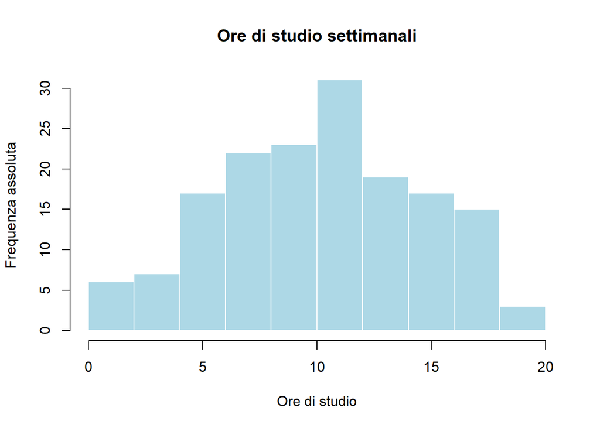

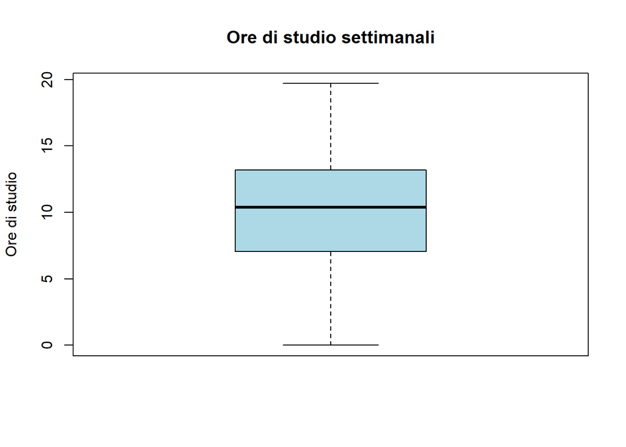

```r
hist(dati$ore_studio,
     col = "lightblue", border = "white",
     main = "Ore di studio settimanali",
     xlab = "Ore di studio", ylab = "Frequenza assoluta")
boxplot(dati$ore_studio,
        col = "lightblue",
        main = "Ore di studio settimanali",
        ylab = "Ore di studio")
```

Media (circa 10.2) e mediana (10.4) sono molto vicine e il boxplot è pressoché simmetrico: la distribuzione delle ore di studio è approssimativamente simmetrica, con il 50% degli studenti che studia tra le 7 e le 13 ore a settimana (primo e terzo quartile).

## 2.6 Esercizio 6

Ripetere l’esercizio 5 per la variabile `ansia`.

```r
summary(dati$ansia)
```

```
   Min. 1st Qu.  Median    Mean 3rd Qu.    Max.
  20.00   44.75   51.00   50.50   56.25   80.00
```

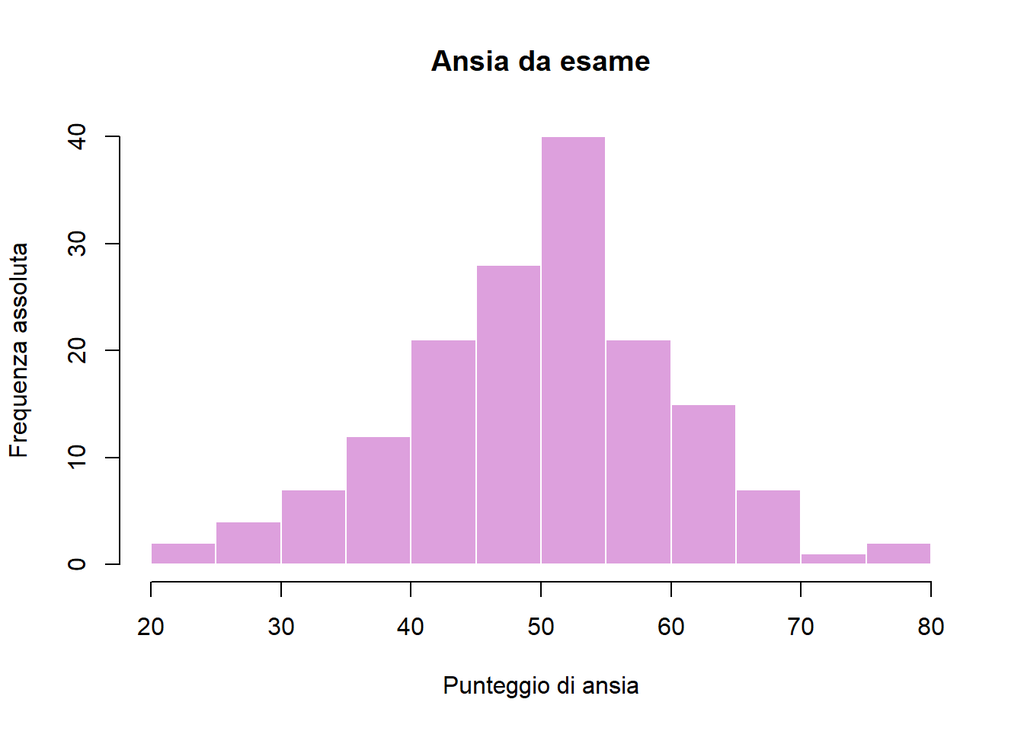

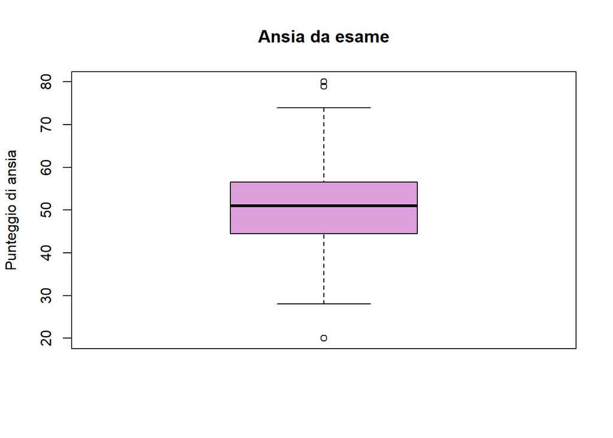

```r
hist(dati$ansia,
     col = "plum", border = "white",
     main = "Ansia da esame",
     xlab = "Punteggio di ansia", ylab = "Frequenza assoluta")
boxplot(dati$ansia,
        col = "plum",
        main = "Ansia da esame",
        ylab = "Punteggio di ansia")
```

Anche in questo caso media (50.5) e mediana (51) sono molto vicine e la distribuzione è approssimativamente simmetrica. Il boxplot evidenzia alcuni valori anomali (punti oltre i baffi) sia nella coda bassa sia in quella alta della distribuzione.

# 3 Tabelle di contingenza e frequenze condizionate

In tutti gli esercizi di questa parte disporre la variabile `frequenza` (o `genere`) sulle **righe** e la variabile `esito` sulle **colonne**.

## 3.1

Costruire la tabella di contingenza tra `frequenza` ed `esito` e salvarla in un oggetto chiamato `tab_fe`. Verificare che la somma di tutte le frequenze congiunte corrisponda all’ampiezza campionaria.

```r
tab_fe = table(dati$frequenza, dati$esito)
tab_fe
```

```
        Non superato Superato
  Bassa           39        9
  Media           26       26
  Alta             5       55
```

```r
sum(tab_fe)   # somma delle frequenze congiunte
```

```
[1] 160
```

```r
nrow(dati)    # ampiezza campionaria
```

```
[1] 160
```

```r
sum(tab_fe) == nrow(dati)
```

```
[1] TRUE
```

## 3.2

A partire da `tab_fe`:

1. calcolare le frequenze marginali di riga (`frequenza`) con `margin.table()`
2. calcolare le frequenze marginali di colonna (`esito`) con `margin.table()`
3. verificare che le frequenze marginali ottenute ai punti a) e b) coincidano con le distribuzioni univariate calcolate nella Parte 1
4. ottenere la tabella di contingenza completa di totali di riga e di colonna con `addmargins()`

```r
# a) marginali di riga (n_k.)
marg_riga = margin.table(tab_fe, 1)
marg_riga
```

```
Bassa Media  Alta
   48    52    60
```

```r
# b) marginali di colonna (n_.j)
marg_col = margin.table(tab_fe, 2)
marg_col
```

```
Non superato     Superato
          70           90
```

```r
# c) confronto con le distribuzioni univariate
marg_riga == table(dati$frequenza)
```

```
Bassa Media  Alta
 TRUE  TRUE  TRUE
```

```r
marg_col == table(dati$esito)
```

```
Non superato     Superato
        TRUE         TRUE
```

```r
# d) tabella con i totali
addmargins(tab_fe)
```

```
        Non superato Superato Sum
  Bassa           39        9  48
  Media           26       26  52
  Alta             5       55  60
  Sum             70       90 160
```

## 3.3

Calcolare le frequenze relative congiunte con `prop.table()`. Che percentuale del campione ha una frequenza alle lezioni alta **e** ha superato l’esame?

```r
prop.table(tab_fe)
```

```
        Non superato Superato
  Bassa      0.24375  0.05625
  Media      0.16250  0.16250
  Alta       0.03125  0.34375
```

```r
round(prop.table(tab_fe) * 100, 1)
```

```
        Non superato Superato
  Bassa         24.4      5.6
  Media         16.2     16.2
  Alta           3.1     34.4
```

Il 34.4% del campione (55 studenti su 160) ha una frequenza alta e ha superato l’esame.

## 3.4

Calcolare le frequenze percentuali **di riga**, $P(\text{Esito} \mid \text{Frequenza})$, arrotondate a una cifra decimale. Completare la frase: *“Il X% degli studenti con frequenza bassa/media/alta ha superato l’esame”*.

```r
perc_riga = round(prop.table(tab_fe, 1) * 100, 1)
perc_riga
```

```
        Non superato Superato
  Bassa         81.2     18.8
  Media         50.0     50.0
  Alta           8.3     91.7
```

```r
# controllo: ogni riga somma a 100
rowSums(perc_riga)
```

```
Bassa Media  Alta
  100   100   100
```

- Il 18.8% degli studenti con frequenza **bassa** ha superato l’esame
- Il 50% degli studenti con frequenza **media** ha superato l’esame
- Il 91.7% degli studenti con frequenza **alta** ha superato l’esame

## 3.5

Calcolare le frequenze percentuali **di colonna**, $P(\text{Frequenza} \mid \text{Esito})$, arrotondate a una cifra decimale. Completare la frase: *“Tra gli studenti che hanno superato l’esame, il X% aveva una frequenza bassa/media/alta”*.

```r
perc_col = round(prop.table(tab_fe, 2) * 100, 1)
perc_col
```

```
        Non superato Superato
  Bassa         55.7     10.0
  Media         37.1     28.9
  Alta           7.1     61.1
```

```r
# controllo: ogni colonna somma a 100
colSums(perc_col)
```

```
Non superato     Superato
        99.9        100.0
```

Tra gli studenti che hanno superato l’esame, il 10% aveva una frequenza bassa, il 28.9% una frequenza media e il 61.1% una frequenza alta. Tra quelli che non l’hanno superato, invece, il 55.7% aveva una frequenza bassa e solo il 7.1% una frequenza alta.

## 3.6

Rappresentare graficamente la relazione tra `frequenza` ed `esito`:

1. con un diagramma a barre affiancate (`barplot()` con `beside = TRUE`) delle frequenze assolute, aggiungendo la legenda
2. con un diagramma a barre affiancate delle frequenze percentuali di riga
3. con un `mosaicplot()`

Sulla base delle tabelle e dei grafici, sembra esserci un’associazione tra la frequenza alle lezioni e l’esito dell’esame?

**Nota**

`barplot()` con una matrice crea un gruppo di barre per ogni **colonna** della matrice. Per avere un gruppo di barre per ogni livello di `frequenza` (che è sulle righe) bisogna quindi trasporre la tabella con `t()`.

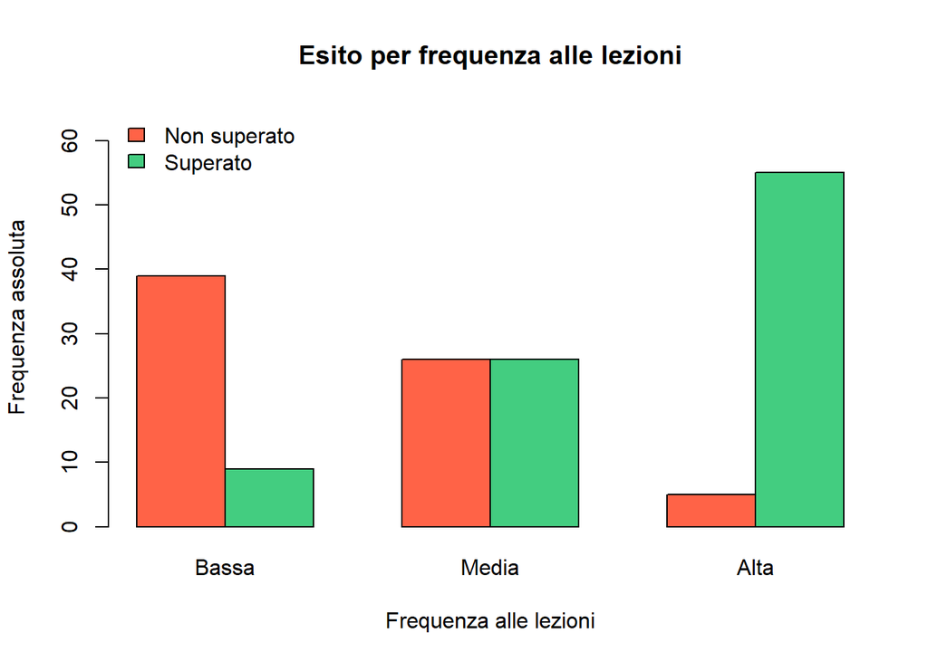

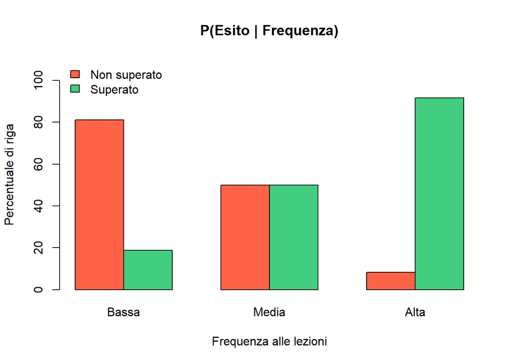

```r
# a) frequenze assolute
barplot(t(tab_fe),
        beside = TRUE,
        col = c("tomato", "seagreen3"),
        legend.text = TRUE,
        args.legend = list(x = "topleft", bty = "n"),
        ylim = c(0, max(tab_fe) + 10),
        main = "Esito per frequenza alle lezioni",
        xlab = "Frequenza alle lezioni",
        ylab = "Frequenza assoluta")
# b) percentuali di riga
barplot(t(perc_riga),
        beside = TRUE,
        col = c("tomato", "seagreen3"),
        legend.text = TRUE,
        args.legend = list(x = "topleft", bty = "n"),
        ylim = c(0, 110),
        main = "P(Esito | Frequenza)",
        xlab = "Frequenza alle lezioni",
        ylab = "Percentuale di riga")
```

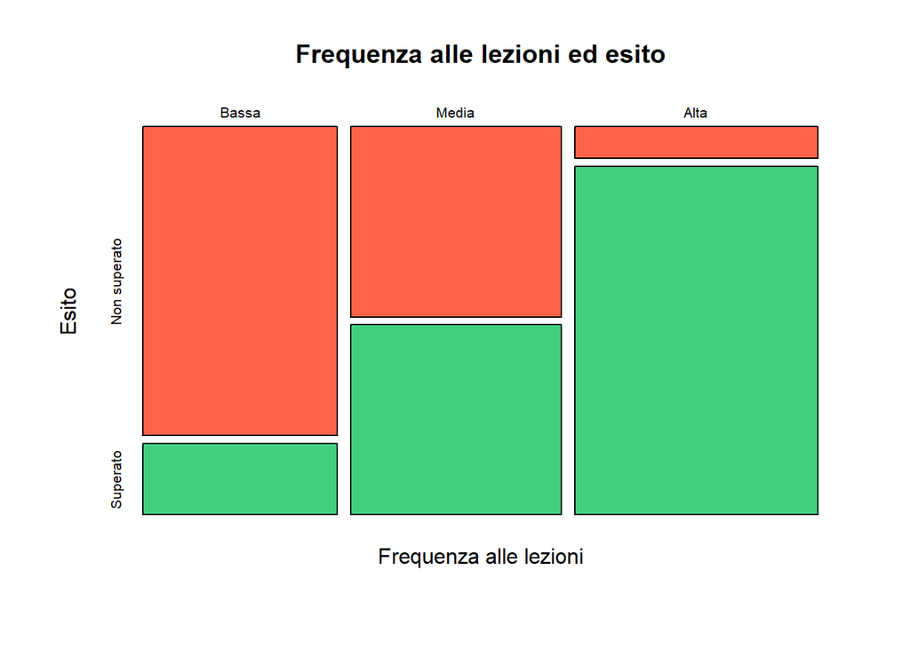

```r
# c) mosaicplot
mosaicplot(tab_fe,
           color = c("tomato", "seagreen3"),
           main = "Frequenza alle lezioni ed esito",
           xlab = "Frequenza alle lezioni",
           ylab = "Esito")
```

Sì: all’aumentare della frequenza alle lezioni aumenta nettamente la percentuale di studenti che supera l’esame (dal 18.8% al 91.7%). Le distribuzioni condizionate dell’esito sono molto diverse tra i tre livelli di frequenza, il che suggerisce che le due variabili non siano indipendenti.

# 4 Connessione e indice $\chi^2$

## 4.1

A partire da `tab_fe`, costruire la tabella delle frequenze teoriche `tab_teo` (ovvero le frequenze che si osserverebbero se `frequenza` ed `esito` fossero indipendenti) utilizzando la formula:

$$n_{kj}^* = \dfrac{n_{k.} \times n_{.j}}{n}$$

Nel calcolo utilizzare le frequenze marginali ottenute con `margin.table()` e un doppio ciclo `for`. Verificare che il totale delle frequenze teoriche sia uguale a quello delle frequenze osservate.

```r
n = sum(tab_fe)
f_riga = margin.table(tab_fe, 1)
f_col = margin.table(tab_fe, 2)

tab_teo = matrix(nrow = nrow(tab_fe), ncol = ncol(tab_fe))
rownames(tab_teo) = rownames(tab_fe)
colnames(tab_teo) = colnames(tab_fe)

for (k in 1:nrow(tab_fe)) {
  for (j in 1:ncol(tab_fe)) {
    tab_teo[k, j] = (f_riga[k] * f_col[j]) / n
  }
}

round(tab_teo, 2)
```

```
      Non superato Superato
Bassa        21.00    27.00
Media        22.75    29.25
Alta         26.25    33.75
```

```r
# controllo dei totali
sum(tab_teo)
```

```
[1] 160
```

```r
sum(tab_fe)
```

```
[1] 160
```

## 4.2

Calcolare il valore dell’indice $\chi^2$

```r
chisq.test(tab_fe)$statistic
```

```
X-squared
 58.83598
```

## 4.3

Calcolare il valore massimo che il $\chi^2$ può assumere per questa tabella, $\chi^2_{\max} = n \times \min[(h-1); (m-1)]$, e il $\chi^2$ normalizzato $\tilde{\chi}^2 = \chi^2 / \chi^2_{\max}$. Commentare il risultato.

```r
chiMax_fe = sum(tab_fe) * min(c(nrow(tab_fe) - 1, ncol(tab_fe) - 1))
chiMax_fe
```

```
[1] 160
```

```r
chisq.test(tab_fe)$statistic / chiMax_fe
```

```
X-squared
0.3677249
```

Con $h = 3$ e $m = 2$, $\chi^2_{\max} = 160 \times \min(2; 1) = 160$. Il $\chi^2$ normalizzato è circa 0.37: le due variabili non sono indipendenti ($\tilde{\chi}^2 > 0$), ma siamo lontani da una relazione di perfetta dipendenza ($\tilde{\chi}^2 = 1$). Si tratta di un’associazione moderata.

## 4.4

Ripetere gli esercizi 7, 10, 13–15 per la coppia di variabili `genere` ed `esito`. Confrontare il $\chi^2$ normalizzato con quello ottenuto per `frequenza` ed `esito`: quale delle due variabili è più associata all’esito dell’esame?

**Avviso**

Per le tabelle $2 \times 2$, `chisq.test()` applica di default una correzione (correzione di Yates). Per ottenere lo stesso valore della formula vista a lezione utilizzare `chisq.test(tabella, correct = FALSE)`. In questo modo, sparisce anche il warning associato.

```r
# tabella di contingenza
tab_ge = table(dati$genere, dati$esito)
addmargins(tab_ge)
```

```
      Non superato Superato Sum
  F             41       53  94
  M             29       37  66
  Sum           70       90 160
```

```r
# percentuali di riga: P(Esito | Genere)
round(prop.table(tab_ge, 1) * 100, 1)
```

```
    Non superato Superato
  F         43.6     56.4
  M         43.9     56.1
```

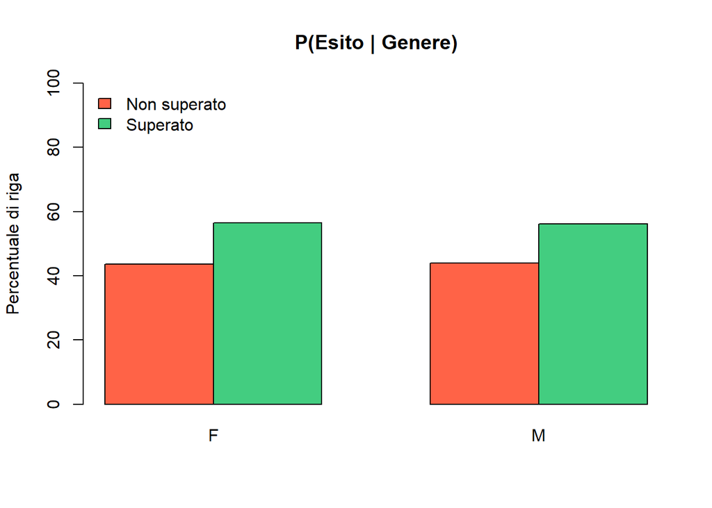

```r
barplot(t(round(prop.table(tab_ge, 1) * 100, 1)),
        beside = TRUE,
        col = c("tomato", "seagreen3"),
        legend.text = TRUE,
        args.legend = list(x = "topleft", bty = "n"),
        ylim = c(0, 100),
        main = "P(Esito | Genere)",
        ylab = "Percentuale di riga")
```

```r
chisq.test(tab_ge)$statistic
```

```
X-squared
        0
```

```r
# chi quadro normalizzato
chiMax_ge = sum(tab_ge) * min(c(nrow(tab_ge) - 1, ncol(tab_ge) - 1))
chiMax_ge
```

```
[1] 160
```

```r
chisq.test(tab_ge)$statistic  / chiMax_ge
```

```
X-squared
        0
```

Le percentuali di superamento sono praticamente identiche per femmine (56.4%) e maschi (56.1%), le frequenze osservate sono quasi uguali a quelle teoriche e il $\chi^2$ normalizzato è praticamente 0: genere ed esito sono (quasi perfettamente) indipendenti. La frequenza alle lezioni ($\tilde{\chi}^2 \approx 0.37$) è quindi molto più associata all’esito dell’esame rispetto al genere.

## 4.5

Studiare l’associazione tra `corso` (sulle righe) e `genere` (sulle colonne): costruire la tabella di contingenza, le frequenze percentuali di riga, un grafico a barre affiancate e calcolare il $\chi^2$ e il $\chi^2$ normalizzato. Commentare.

```r
tab_cg = table(dati$corso, dati$genere)
addmargins(tab_cg)
```

```
               F   M Sum
  Economia    25  30  55
  Ingegneria  12  22  34
  Psicologia  57  14  71
  Sum         94  66 160
```

```r
perc_riga_cg = round(prop.table(tab_cg, 1) * 100, 1)
perc_riga_cg
```

```
                F    M
  Economia   45.5 54.5
  Ingegneria 35.3 64.7
  Psicologia 80.3 19.7
```

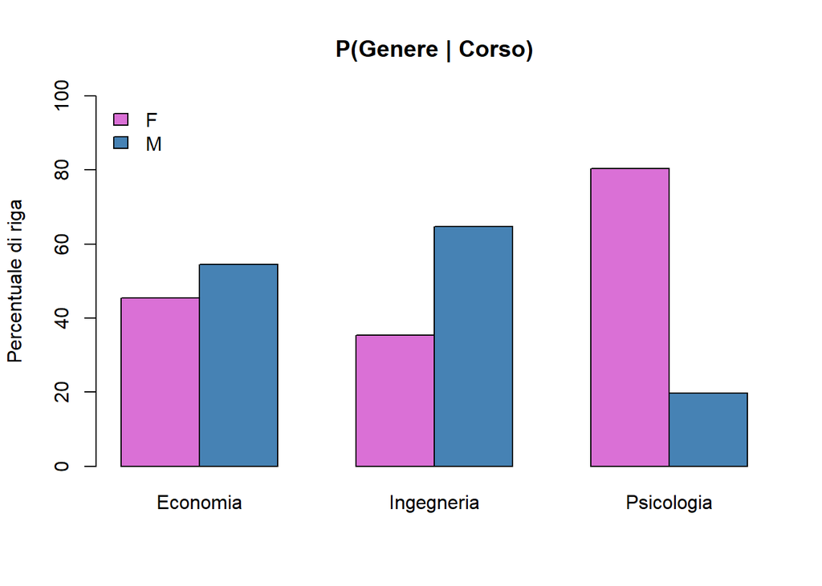

```r
barplot(t(perc_riga_cg),
        beside = TRUE,
        col = c("orchid", "steelblue"),
        legend.text = TRUE,
        args.legend = list(x = "topleft", bty = "n"),
        ylim = c(0, 100),
        main = "P(Genere | Corso)",
        ylab = "Percentuale di riga")
```

```r
chisq.test(tab_cg)$expected
```

```
                   F       M
  Economia   32.3125 22.6875
  Ingegneria 19.9750 14.0250
  Psicologia 41.7125 29.2875
```

```r
chi2_cg = chisq.test(tab_cg)$statistic
chi2_cg
```

```
X-squared
 25.31319
```

```r
chiMax_cg = sum(tab_cg) * min(c(nrow(tab_cg) - 1, ncol(tab_cg) - 1))
chiMax_cg
```

```
[1] 160
```

```r
chi2_cg / chiMax_cg
```

```
X-squared
0.1582074
```

La composizione per genere cambia tra i corsi: a Psicologia l’80.3% sono femmine, a Economia la distribuzione è circa bilanciata (45.5% femmine), a Ingegneria prevalgono i maschi (64.7%). Il $\chi^2$ normalizzato (circa 0.16) indica un’associazione presente ma debole.

## 4.6

Studiare se vi sia un’associazione tra il fatto di studiare **almeno 10 ore a settimana** e l’esito dell’esame. Costruire la tabella di contingenza utilizzando una condizione logica (`dati$ore_studio >= 10`), rinominare righe e colonne in modo che siano facilmente leggibili, e calcolare frequenze percentuali di riga, $\chi^2$ e $\chi^2$ normalizzato.

```r
tab_oe = table(dati$ore_studio >= 10, dati$esito)
tab_oe  # FALSE = meno di 10 ore, TRUE = almeno 10 ore
```

```
        Non superato Superato
  FALSE           53       20
  TRUE            17       70
```

```r
rownames(tab_oe) = c("< 10 ore", ">= 10 ore")
addmargins(tab_oe)
```

```
            Non superato Superato Sum
  < 10 ore            53       20  73
  >= 10 ore           17       70  87
  Sum                 70       90 160
```

```r
round(prop.table(tab_oe, 1) * 100, 1)
```

```
            Non superato Superato
  < 10 ore          72.6     27.4
  >= 10 ore         19.5     80.5
```

```r
# tabella 2x2: correct = FALSE
chi2_oe = chisq.test(tab_oe, correct = FALSE)$statistic
chi2_oe
```

```
X-squared
 45.41477
```

```r
chiMax_oe = sum(tab_oe) * min(c(nrow(tab_oe) - 1, ncol(tab_oe) - 1))
chi2_oe / chiMax_oe
```

```
X-squared
0.2838423
```

Supera l’esame l’80.5% di chi studia almeno 10 ore a settimana, contro il 27.4% di chi studia meno di 10 ore. Il $\chi^2$ normalizzato (circa 0.28) indica un’associazione moderata tra le due variabili.

# 5 Indipendenza stocastica e massima dipendenza

## 5.1

Un’indagine ha rilevato la modalità di studio preferita (`da solo`, `in gruppo`, `misto`) in tre corsi di laurea. Le frequenze osservate sono:

|  | Psicologia | Economia | Ingegneria |
| --- | --- | --- | --- |
| da solo | 20 | 30 | 10 |
| in gruppo | 12 | 18 | 6 |
| misto | 8 | 12 | 4 |

1. inserire i dati in una matrice `tab_ind`, assegnando i nomi a righe e colonne
2. calcolare le frequenze percentuali di colonna e rappresentarle con un diagramma a barre affiancate. Cosa si nota?
3. calcolare le frequenze teoriche e confrontarle con quelle osservate
4. calcolare il $\chi^2$ e il $\chi^2$ normalizzato. Che tipo di relazione c’è tra le due variabili?

```r
# a)
tab_ind = matrix(c(20, 30, 10,
                   12, 18,  6,
                    8, 12,  4),
                 nrow = 3, byrow = TRUE)
rownames(tab_ind) = c("da solo", "in gruppo", "misto")
colnames(tab_ind) = c("Psicologia", "Economia", "Ingegneria")
addmargins(tab_ind)
```

```
          Psicologia Economia Ingegneria Sum
da solo           20       30         10  60
in gruppo         12       18          6  36
misto              8       12          4  24
Sum               40       60         20 120
```

```r
# b)
perc_col_ind = round(prop.table(tab_ind, 2) * 100, 1)
perc_col_ind
```

```
          Psicologia Economia Ingegneria
da solo           50       50         50
in gruppo         30       30         30
misto             20       20         20
```

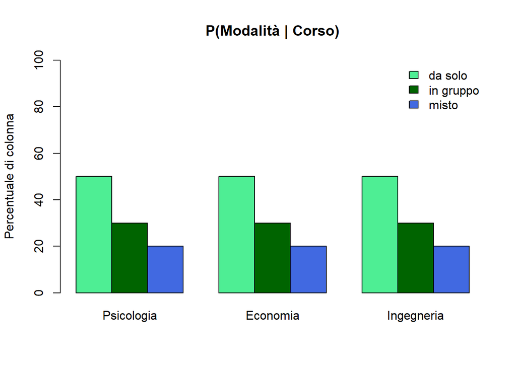

```r
barplot(perc_col_ind,
        beside = TRUE,
        col = c("seagreen2", "darkgreen", "royalblue"),
        legend.text = TRUE,
        args.legend = list(x = "topright", bty = "n"),
        ylim = c(0, 100),
        main = "P(Modalità | Corso)",
        ylab = "Percentuale di colonna")
```

Le distribuzioni percentuali di colonna sono identiche nei tre corsi (50% da solo, 30% in gruppo, 20% misto): la modalità di studio preferita non cambia al variare del corso.

```r
# c)
chisq.test(tab_ind)$expected
```

```
          Psicologia Economia Ingegneria
da solo           20       30         10
in gruppo         12       18          6
misto              8       12          4
```

```r
tab_ind == chisq.test(tab_ind)$expected
```

```
          Psicologia Economia Ingegneria
da solo         TRUE     TRUE       TRUE
in gruppo       TRUE     TRUE       TRUE
misto           TRUE     TRUE       TRUE
```

```r
# d)
chi2_ind = chisq.test(tab_ind)$statistic
chi2_ind
```

```
X-squared
        0
```

```r
chiMax_ind = sum(tab_ind) * min(c(nrow(tab_ind) - 1, ncol(tab_ind) - 1))
chiMax_ind
```

```
[1] 240
```

```r
chi2_ind / chiMax_ind
```

```
X-squared
        0
```

Le frequenze osservate coincidono con quelle teoriche, quindi $\chi^2 = 0$ e $\tilde{\chi}^2 = 0$: le due variabili sono **stocasticamente indipendenti**.

## 5.2

Si consideri ora la seguente tabella:

|  | Psicologia | Economia | Ingegneria |
| --- | --- | --- | --- |
| da solo | 40 | 0 | 0 |
| in gruppo | 0 | 60 | 0 |
| misto | 0 | 0 | 20 |

Ripetere i punti a)–d) dell’esercizio 20. Confrontare il valore del $\chi^2$ con il $\chi^2_{\max}$: che tipo di relazione c’è tra le due variabili?

```r
# a)
tab_dip = matrix(c(40,  0,  0,
                    0, 60,  0,
                    0,  0, 20),
                 nrow = 3, byrow = TRUE)
rownames(tab_dip) = c("da solo", "in gruppo", "misto")
colnames(tab_dip) = c("Psicologia", "Economia", "Ingegneria")
addmargins(tab_dip)
```

```
          Psicologia Economia Ingegneria Sum
da solo           40        0          0  40
in gruppo          0       60          0  60
misto              0        0         20  20
Sum               40       60         20 120
```

```r
# b)
perc_col_dip = round(prop.table(tab_dip, 2) * 100, 1)
perc_col_dip
```

```
          Psicologia Economia Ingegneria
da solo          100        0          0
in gruppo          0      100          0
misto              0        0        100
```

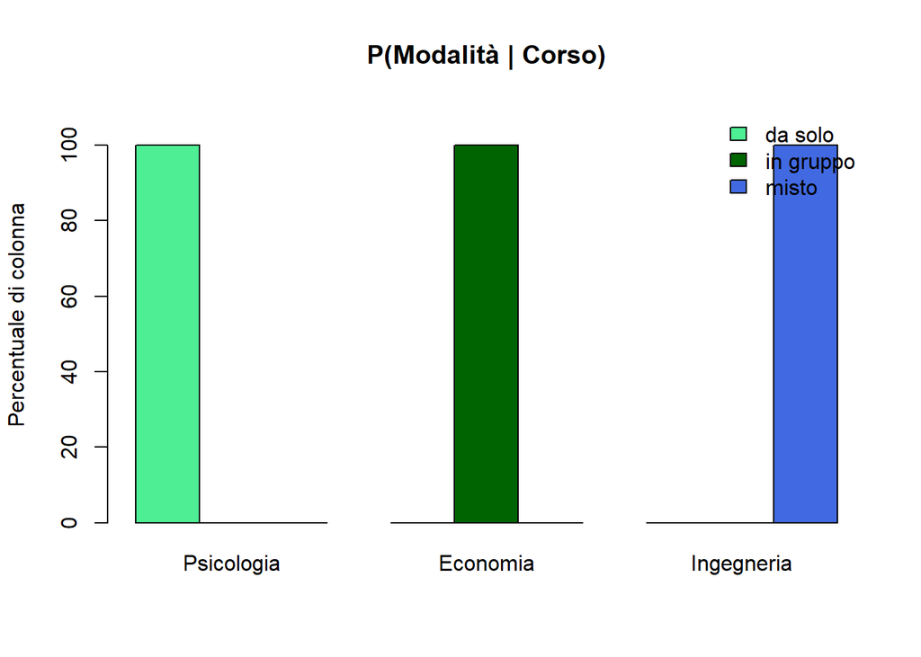

```r
barplot(perc_col_dip,
        beside = TRUE,
        col = c("seagreen2", "darkgreen", "royalblue"),
        legend.text = TRUE,
        args.legend = list(x = "topright", bty = "n"),
        ylim = c(0, 110),
        main = "P(Modalità | Corso)",
        ylab = "Percentuale di colonna")
```

Ogni corso è associato a una sola modalità di studio: conoscendo il corso si conosce con certezza la modalità di studio preferita (e viceversa).

```r
# c)
round(chisq.test(tab_dip)$expected, 2)
```

```
          Psicologia Economia Ingegneria
da solo        13.33       20       6.67
in gruppo      20.00       30      10.00
misto           6.67       10       3.33
```

```r
# d)
chi2_dip = chisq.test(tab_dip)$statistic
chi2_dip
```

```
X-squared
      240
```

```r
chiMax_dip = sum(tab_dip) * min(c(nrow(tab_dip) - 1, ncol(tab_dip) - 1))
chiMax_dip
```

```
[1] 240
```

```r
chi2_dip / chiMax_dip
```

```
X-squared
        1
```

Le frequenze osservate sono molto diverse da quelle teoriche. Il $\chi^2$ (240) coincide con il suo valore massimo $\chi^2_{\max} = 120 \times \min(2; 2) = 240$, quindi $\tilde{\chi}^2 = 1$: tra le due variabili c’è una relazione di **perfetta dipendenza**.